# Homework 02 (Worked)

# Homework 02 — Questions with Worked Solutions

## Question 1: Training and test error under a fixed design

**Setup.** $n=100$, $p=20$ covariates, $\mathbf X_{\mathrm{all}}$ generated once (seed `43202`) and held fixed. $\beta_j = 0.4^{\sqrt j}$, $\boldsymbol\mu = \mathbf X_{\mathrm{all}}\boldsymbol\beta$. Independent training/test responses $\mathbf y=\boldsymbol\mu+\boldsymbol\epsilon$, $\mathbf y^*=\boldsymbol\mu+\boldsymbol\epsilon^*$ are drawn 200 times.

### a. Average training and test MSE vs. $m$

The plot below shows the simulation averages together with the theoretical expectations from part (b), plus one raw test-MSE curve from part (c).

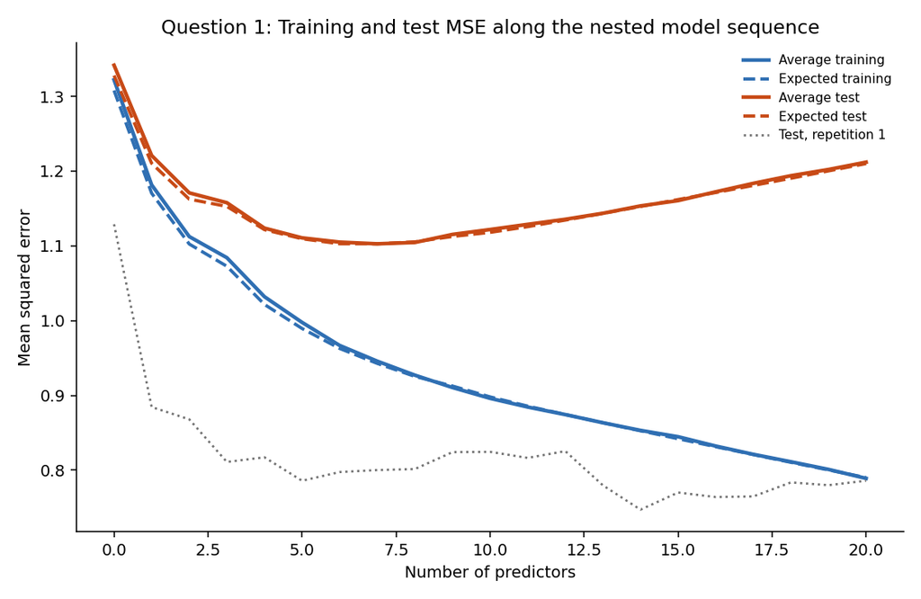

Question 1 simulation

Selected numerical values (average over 200 repetitions):

| $m$ | Average train | $E(\text{train})$ | Average test | $E(\text{test})$ |
| --- | --- | --- | --- | --- |
| 0 | 1.3220 | 1.3078 | 1.3416 | 1.3278 |
| 5 | 0.9976 | 0.9894 | 1.1107 | 1.1094 |
| 10 | 0.8960 | 0.8980 | 1.1218 | 1.1180 |
| 15 | 0.8446 | 0.8419 | 1.1605 | 1.1619 |
| 20 | 0.7889 | 0.7900 | 1.2119 | 1.2100 |

Numerically, training MSE was verified to be **non-increasing along every one of the 200 simulation runs** (each run’s sequence of 21 training MSEs, $m=0,\dots,20$, has no positive increment to within numerical tolerance). This must hold because each larger model’s column space contains the smaller model’s column space, so the least-squares fit can only get weakly closer to $\mathbf y$ in-sample.

### b. Theoretical expectations

Using
$$E(\operatorname{MSE}_{\mathrm{train},m}\mid \mathbf X_{\mathrm{all}}) =
\frac{B_m^2}{n}+1-\frac{m+1}{n},
\qquad
E(\operatorname{MSE}_{\mathrm{test},m}\mid \mathbf X_{\mathrm{all}}) =
\frac{B_m^2}{n}+1+\frac{m+1}{n},$$
the theoretical curves track the simulation averages closely (table above), with the small remaining gap attributable to Monte Carlo error over 200 repetitions. Both the simulated and theoretical average test MSE are minimized at $m=7$.

### c. A single test-MSE run, and why training MSE alone is insufficient

A single simulation’s test-MSE curve (dotted gray line in the figure) is much less smooth than the 200-run average, because it retains the full sampling variability of one particular noise vector $\boldsymbol\epsilon^*$ (and of $\boldsymbol\epsilon$, through $\widehat{\mathbf y}_m$); averaging over repetitions cancels this noise and leaves only the systematic trend.

Expected test MSE decomposes into the mean squared approximation bias $B_m^2/n$ (which is non-increasing in $m$, since adding predictors can only shrink the bias) and an estimation-variance term $+(m+1)/n$ (which strictly increases in $m$). Training MSE instead has $-(m+1)/n$: adding parameters *lowers* apparent training error even when it buys no real reduction in bias, because the fit is absorbing noise rather than signal. So training MSE, taken alone, will always favor the largest model and cannot reveal the point where added variance starts to outweigh the bias reduction — only a genuinely out-of-sample (or theoretically corrected) criterion can do that.

## Question 2: Prediction error at one target point

**Setup.** $n=100$, $p=6$, orthogonal cosine design (columns satisfy $\mathbf 1^{\mathsf T}\mathbf X_{\mathrm{all}}=\mathbf 0$, $\tfrac1n\mathbf X_{\mathrm{all}}^{\mathsf T}\mathbf X_{\mathrm{all}}=\mathbf I_p$), $\boldsymbol\beta=(0.5,\dots,0.5)^{\mathsf T}$, target $\mathbf x_0=(0,1,0,0,1,0)^{\mathsf T}$.

### a. Theoretical bias, variance, and expected squared error

$\mu_0 = \mathbf x_0^{\mathsf T}\boldsymbol\beta = 0.5+0.5 = 1$.

Because the design columns are centered and orthogonal, an omitted predictor’s contribution to $\mu_0$ is simply left out of the fit (bias), while each *included* coefficient contributes an independent $\sigma^2/n$ (or $\sigma^2 x_{0j}^2/n$) to the estimation variance — these add because the coefficient estimates are uncorrelated under this design.

| $m$ | Squared bias | Estimation variance | $E[(\widehat\mu_{0,m}-\mu_0)^2]$ |
| --- | --- | --- | --- |
| 0 | 1.00 | 0.01 | 1.01 |
| 1 | 1.00 | 0.01 | 1.01 |
| 2 | 0.25 | 0.02 | 0.27 |
| 3 | 0.25 | 0.02 | 0.27 |
| 4 | 0.25 | 0.02 | 0.27 |
| 5 | 0.00 | 0.03 | 0.03 |
| 6 | 0.00 | 0.03 | 0.03 |

The error changes only when predictor 2 or predictor 5 is added (at $m=2$ and $m=5$); it is flat across $m=0\to1$, $m=2\to4$, and $m=5\to6$, since predictors 1, 3, 4, and 6 have $x_{0j}=0$ and so are irrelevant to this particular target.

### b. Simulation (seed `43203`, 200 repetitions)

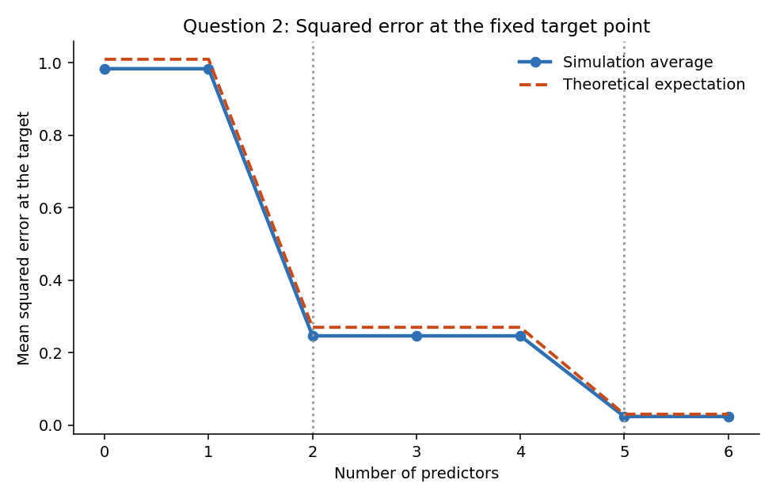

Question 2 simulation

| $m$ | Simulated | Theoretical |
| --- | --- | --- |
| 0 | 0.9839 | 1.0100 |
| 1 | 0.9839 | 1.0100 |
| 2 | 0.2464 | 0.2700 |
| 3 | 0.2464 | 0.2700 |
| 4 | 0.2464 | 0.2700 |
| 5 | 0.0237 | 0.0300 |
| 6 | 0.0237 | 0.0300 |

The smallest $m$ that minimizes the theoretical expected squared error is **$m=5$**.

### c. Why only predictors 2 and 5 matter here

All six coefficients are nonzero, but $\mathbf x_0$ itself is zero in coordinates 1, 3, 4, and 6 — so those coefficients get multiplied by zero when forming the prediction at this specific point, and only coordinates 2 and 5 actually enter $\mu_0=\mathbf x_0^{\mathsf T}\boldsymbol\beta$. This is a *target-specific* statement: it says nothing about whether those predictors matter elsewhere. By contrast, the average test MSE in Question 1 averages error over **all rows** of the design, so a predictor with nonzero values spread across many rows can matter a great deal for average prediction even while contributing nothing to the prediction at one particular $\mathbf x_0$ where its coordinate happens to be zero.

## Question 3: The optimism correction

### a. Derivation

Write $\mathbf y-\mathbf H\mathbf y = (\mathbf I_n-\mathbf H)\boldsymbol\mu + (\mathbf I_n-\mathbf H)\boldsymbol\epsilon$. The cross term has mean zero, and since $\mathbf I_n-\mathbf H$ is symmetric idempotent with trace $n-(p+1)$,
$$E\big(\lVert \mathbf y-\mathbf H\mathbf y\rVert_2^2\mid \mathbf X\big) =
B^2 + \sigma^2\big(n-(p+1)\big)
\;\;\Longrightarrow\;\;
E(\operatorname{MSE}_{\mathrm{train}}\mid\mathbf X) =
\frac{B^2}{n}+\sigma^2\Big(1-\frac{p+1}{n}\Big).$$

For the independent test response, $\mathbf y^*-\mathbf H\mathbf y = (\mathbf I_n-\mathbf H)\boldsymbol\mu + \boldsymbol\epsilon^* - \mathbf H\boldsymbol\epsilon$; all cross terms vanish in expectation, and independence of $\boldsymbol\epsilon,\boldsymbol\epsilon^*$ gives $E(\lVert\boldsymbol\epsilon^*-\mathbf H\boldsymbol\epsilon\rVert_2^2\mid\mathbf X) = n\sigma^2+\sigma^2\operatorname{tr}(\mathbf H) = \sigma^2(n+(p+1))$, so
$$E(\operatorname{MSE}_{\mathrm{test}}\mid\mathbf X) =
\frac{B^2}{n}+\sigma^2\Big(1+\frac{p+1}{n}\Big).$$

### b. Expected optimism

$$E(\operatorname{MSE}_{\mathrm{test}}-\operatorname{MSE}_{\mathrm{train}}\mid\mathbf
X) = \frac{2(p+1)\sigma^2}{n}.$$

For $n=120,\ p=4,\ B^2/n=0.04,\ \sigma^2=1$:
$$E(\operatorname{MSE}_{\mathrm{train}}) =
0.04+1-\tfrac{5}{120}=0.998333,\qquad
E(\operatorname{MSE}_{\mathrm{test}}) = 0.04+1+\tfrac{5}{120}=1.081667,$$
difference $=0.083333$. These are long-run (expected) statements; for any one realized pair $(\mathbf y,\mathbf y^*)$ the noise can go either way, so a particular test MSE can come out smaller than its paired training MSE even though the ordering holds *on average*.

### c. $C_p$ and corrected test MSE, $n=120,\ p=4,\ \operatorname{RSS}=116.4,\ \widehat\sigma^2=0.96$

$$\widehat{\operatorname{MSE}}_{\mathrm{test}} =
\frac{116.4+2(5)(0.96)}{120} = 1.05,
\qquad
C_p = \frac{116.4}{0.96}-120+2(5) = 11.25.$$

They are related by $\widehat{\operatorname{MSE}}_{\mathrm{test}} = \dfrac{\widehat\sigma^2(C_p+n)}{n}$ (check: $0.96(11.25+120)/120 = 1.05$). Since $n$ and $\widehat\sigma^2$ are shared across candidate models, this map from $C_p$ to $\widehat{\operatorname{MSE}}_{\mathrm{test}}$ is a common increasing affine transformation, so minimizing $C_p$ and minimizing the corrected test MSE always select the same model.

## Question 4: Comparing Mallows’ $C_p$, AIC, and BIC

*(Requires `data/diabetes.csv`, rows 1–370; not available in this environment, so the numbers below reproduce the official solution’s reported values rather than being freshly recomputed here.)*

### a. Fits

Full reference model residual degrees of freedom: $n-(p+1) = 370-11 = 359$. Estimated common noise variance: $\widehat\sigma^2 = \operatorname{RSS}_{\mathrm{full}}/359 \approx 3034.684$.

### b. Criteria for Models A and B

| Model | $p$ | RSS | $C_p$ | Reduced AIC | Reduced BIC |
| --- | --- | --- | --- | --- | --- |
| A | 7 | 1,098,908.566 | 8.116 | 2,974.640 | 3,005.948 |
| B | 8 | 1,089,717.057 | 7.087 | 2,973.532 | 3,008.754 |

$C_p$ and AIC both select **Model B**; BIC selects **Model A**. (Each criterion is only compared against itself, not across criteria.)

### c. Why the disagreement, and what selection does *not* prove

Adding `s6` improves the AIC/BIC fit term by $n\log(\operatorname{RSS}_A/\operatorname{RSS}_B) \approx 3.108$ and the $C_p$-scale gain is $(\operatorname{RSS}_A-\operatorname{RSS}_B)/\widehat\sigma^2 \approx 3.029$. AIC’s and $C_p$’s per-parameter penalty is $2$, which this improvement clears, so both accept `s6`. BIC’s penalty is $\log(370)\approx 5.914$, which the improvement does *not* clear, so BIC rejects it. The criteria disagree simply because they encode different complexity penalties (BIC penalizes additional parameters more heavily as $n$ grows). Selecting a model by any one of these criteria only shows it best trades off fit and complexity *under that criterion’s assumptions* among the candidates considered — it does not establish that the selected model is the true data-generating process, which may not even be linear in the available predictors.

## Question 5: Validation and final test data

### a. Where the procedure goes wrong

The misuse begins at **step 2**: computing MSE on the final test set for all eleven candidates and then (step 3) picking the smallest uses the final test responses to make a *model-selection* decision, even though the coefficients themselves were fit only on training data. Because each candidate’s test MSE contains independent sampling noise, taking the minimum over eleven candidates preferentially selects whichever model got a lucky (unusually low) noise realization on that particular test set. Reporting that same minimum as the estimate of future prediction error is therefore optimistic — it has effectively been “peeked at” during selection and no longer measures error on unseen data for the chosen procedure.

### b. A valid five-fold cross-validation procedure

1. Set aside rows 371–442 untouched.
2. Split rows 1–370 into 5 folds.
3. For each candidate predictor count $m=0,\dots,10$: fit on 4 folds, evaluate MSE on the held-out fold; rotate through all 5 folds and average the 5 MSE values.
4. Select the $m$ with the smallest average cross-validated MSE.
5. Refit the chosen model using **all 370** training rows.
6. Only now evaluate this single, already-selected, refit model **once** on rows 371–442 to obtain the final prediction-error estimate.

### c. If the eleven test MSE values were already examined

Those eleven numbers can still be reported honestly, but only as **exploratory** results — for instance, describing the general pattern (e.g., where error bottoms out) — not as a valid final performance estimate, since the selection step has already contaminated that data. A trustworthy final evaluation would require a **new**, previously unseen test set (or genuinely new future observations) that was not involved in any part of the model-selection process.

## Key ideas

1. Under a fixed design, training and test responses differ only through independent response noise.
2. Average prediction error and prediction error at one target point can favor different predictor counts.
3. The fixed-design optimism correction is $2(p+1)\sigma^2/n$.
4. Mallows’ $C_p$, AIC, and BIC can disagree because they use different complexity penalties.
5. A final test set is valid only if it remains untouched until the entire procedure has been chosen.